# Exercicio3

```python
import networkx as nx

#Load GraphMissingEdges
G = nx.read_gml("../GraphMissingEdges.gml")
```

```python
def compute_centrality(centrality_callback):
    # Compute degree centrality
    degree_centrality = centrality_callback(G)

    # Sort nodes by degree centrality and get top 50
    top_50_degree_centrality = sorted(degree_centrality.items(), key=lambda x: x[1], reverse=True)[:50]

    # Print top 50 places with their categories
    print("Top 50 places according to centrality:")
    for node, centrality in top_50_degree_centrality:
        print(f"Place: {G.nodes[node].get('name','Empty')}")
        print(f"Centrality: {centrality}")
        print(f"Categories: {G.nodes[node]['categories']}\n")
```

## 1- Usando a rede do desafio "GraphMissingEdges.gml", faça o que é pedido abaixo.

### a- Compute a centralidade de grau e identifique os top 50 lugares de acordo com essa métrica. Mostre o nome e categorias dos lugares.

```python
compute_centrality(nx.degree_centrality)
```

```
Top 50 places according to centrality:
Place: Gaucho Parrilla Argentina
Centrality: 0.050721469173589856
Categories: 221,64,1,83

Place: Condado Tacos
Centrality: 0.04897245299519021
Categories: 1,393,275,208,58,651

Place: Noodlehead
Centrality: 0.04634892872759073
Categories: 370,1,620,641

Place: täkō
Centrality: 0.04459991254919108
Categories: 1,420,651

Place: Bakersfield
Centrality: 0.04175776125929165
Categories: 58,275,393,208,420,83,651,1

Place: Smallman Galley
Centrality: 0.040008745080892
Categories: 275,604,420,173,1,58,641

Place: Meat & Potatoes
Centrality: 0.03738522081329253
Categories: 428,641,262,490,420,1,188

Place: DiAnoia's Eatery
Centrality: 0.03694796676869261
Categories: 1,287,289,405

Place: Piada Italian Street Food
Centrality: 0.034324442501093136
Categories: 741,1,405,46

Place: Banh Mi & Ti
Centrality: 0.028858766943594228
Categories: 1,362,857,204,641
```

[output cut: 145 more lines]

```
Place: Ten Penny
Centrality: 0.016834280717096632
Categories: 1,420,604

Place: Coca Cafe
Centrality: 0.016615653694796676
Categories: 162,641,1,370,173,420

Place: Mount Everest Sushi
Centrality: 0.016615653694796676
Categories: 550,1,870,217,641,844,861

Place: The Urban Tap
Centrality: 0.016615653694796676
Categories: 420,602,741,188,1,604,289
```

### b- Compute a centralidade de intermediação e identifique os top 50 lugares de acordo com essa métrica. Mostre o nome e categorias dos lugares.

```python
# Compute betweenness centrality
compute_centrality(nx.betweenness_centrality)
```

```
Top 50 places according to centrality:
Place: Gaucho Parrilla Argentina
Centrality: 0.03831476818769258
Categories: 221,64,1,83

Place: Condado Tacos
Centrality: 0.03497635736098004
Categories: 1,393,275,208,58,651

Place: Noodlehead
Centrality: 0.031020182749383823
Categories: 370,1,620,641

Place: täkō
Centrality: 0.030039107496056698
Categories: 1,420,651

Place: Bakersfield
Centrality: 0.028527549889386276
Categories: 58,275,393,208,420,83,651,1

Place: Smallman Galley
Centrality: 0.024649600640238006
Categories: 275,604,420,173,1,58,641

Place: Meat & Potatoes
Centrality: 0.02246955292840512
Categories: 428,641,262,490,420,1,188

Place: DiAnoia's Eatery
Centrality: 0.020927805660861522
Categories: 1,287,289,405

Place: Piada Italian Street Food
Centrality: 0.017681677144784098
Categories: 741,1,405,46

Place: City Works - Pittsburgh
Centrality: 0.014176254796523331
Categories: 420,100,612,604,1,58,341,275
```

[output cut: 145 more lines]

```
Place: Nicky's Thai Kitchen
Centrality: 0.00597512060471229
Categories: 370,575,1,83,496,641

Place: The Yard
Centrality: 0.005749348949567221
Categories: 420,58,1,188,275

Place: Tres Rios
Centrality: 0.005667580773900581
Categories: 208,275,1,651,58

Place: The Milk Shake Factory
Centrality: 0.005625789251873097
Categories: 641,653,838,575,262
```

### c- Compute a centralidade de proximidade e identifique os top 50 lugares de acordo com essa métrica.

```python
# Compute closeness centrality
compute_centrality(nx.closeness_centrality)
```

```
Top 50 places according to centrality:
Place: Gaucho Parrilla Argentina
Centrality: 0.3386633071802575
Categories: 221,64,1,83

Place: täkō
Centrality: 0.3366922122688829
Categories: 1,420,651

Place: Condado Tacos
Centrality: 0.3361849274032173
Categories: 1,393,275,208,58,651

Place: Smallman Galley
Centrality: 0.3337425582725102
Categories: 275,604,420,173,1,58,641

Place: Bakersfield
Centrality: 0.33370690582530665
Categories: 58,275,393,208,420,83,651,1

Place: Noodlehead
Centrality: 0.33228702748970274
Categories: 370,1,620,641

Place: Meat & Potatoes
Centrality: 0.3320045005240403
Categories: 428,641,262,490,420,1,188

Place: DiAnoia's Eatery
Centrality: 0.33140572304590443
Categories: 1,287,289,405

Place: Pork & Beans
Centrality: 0.3218452859499995
Categories: 604,1,208,612,58,275,437,706,133,641,289,613,330

Place: Piada Italian Street Food
Centrality: 0.3211834613850191
Categories: 741,1,405,46
```

[output cut: 145 more lines]

```
Place: The Yard
Centrality: 0.30097604253113935
Categories: 420,58,1,188,275

Place: Mount Everest Sushi
Centrality: 0.3008021517025224
Categories: 550,1,870,217,641,844,861

Place: The Vandal
Centrality: 0.2995617899338987
Categories: 1,420,366,362,275,818,162,173,49,248,58,289,641

Place: B52 Cafe
Centrality: 0.2995043475964233
Categories: 496,158,636,173,162,641,362,1
```

### d- Compute a centralidade de autovetor e identifique os top 50 lugares de acordo com essa métrica.

```python
# Compute eigenvector centrality
compute_centrality(nx.eigenvector_centrality)
```

```
Top 50 places according to centrality:
Place: Gaucho Parrilla Argentina
Centrality: 0.17456964773391076
Categories: 221,64,1,83

Place: täkō
Centrality: 0.17190394434341297
Categories: 1,420,651

Place: Bakersfield
Centrality: 0.16320439180386453
Categories: 58,275,393,208,420,83,651,1

Place: Condado Tacos
Centrality: 0.16158529631224822
Categories: 1,393,275,208,58,651

Place: DiAnoia's Eatery
Centrality: 0.1587964106212814
Categories: 1,287,289,405

Place: Meat & Potatoes
Centrality: 0.15563920649505192
Categories: 428,641,262,490,420,1,188

Place: Smallman Galley
Centrality: 0.15546589064767946
Categories: 275,604,420,173,1,58,641

Place: Noodlehead
Centrality: 0.14667106736644028
Categories: 370,1,620,641

Place: Piada Italian Street Food
Centrality: 0.12540629451729368
Categories: 741,1,405,46

Place: Pork & Beans
Centrality: 0.11927850877329998
Categories: 604,1,208,612,58,275,437,706,133,641,289,613,330
```

[output cut: 145 more lines]

```
Place: Monterey Bay Fish Grotto
Centrality: 0.0632887191678829
Categories: 208,366,58,83,275,1

Place: Casellula
Centrality: 0.0631066313101625
Categories: 366,420,275,612,1,58

Place: Istanbul Sofra
Centrality: 0.06309213401433779
Categories: 891,447,79,1,158,189,641

Place: Morcilla
Centrality: 0.06285859236663653
Categories: 562,1
```

### e- Interprete os resultados obtidos nas letras a, b e c. O que pode explicar as diferenças nos ranqueamentos? Dica, interprete o que a métrica captura. Esse resultado é inesperado de alguma forma?

- **Grau:** Captura o número de conexões de um nó. Lugares com alto grau de centralidade são aqueles com muitas conexões diretas. Isso pode indicar locais populares ou centrais na rede.
- **Intermediação:** Captura a frequência com que um nó aparece nos caminhos mais curtos entre outros nós. Lugares com alta intermediação são aqueles que estão no caminho entre muitos outros lugares. Eles podem atuar como pontos de trânsito ou de passagem na rede.
- **Proximidade:** Captura a distância média de um nó para todos os outros nós na rede. Lugares com alta proximidade são aqueles que estão mais próximos de todos os outros lugares na rede. Isso pode indicar locais facilmente acessíveis ou centrais em termos de distância.

Podemos notar que Gaucho Parrilla Argentina é o nó de maior centralidade em todos os resultados.

Sobre as diferenças nos ranqueamentos, elas podem ser explicadas pelas diferentes perspectivas que cada métrica captura. Por exemplo, um lugar pode ter muitas conexões diretas (alto grau de centralidade), mas não estar necessariamente no caminho entre outros lugares (baixa intermediação). Da mesma forma, um lugar pode estar próximo de todos os outros lugares (alta proximidade), mas não necessariamente ter muitas conexões diretas (baixo grau de centralidade). Portanto, é esperado que as diferentes métricas identifiquem lugares diferentes como os mais importantes, dependendo das características da rede e do que está sendo analisado.

## 2- Considere a seguinte rede e responda as questões abaixo.

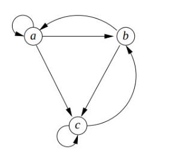

### a- O que acontece com as valores de PageRank dos nós conforme você aumenta o parâmetro de amortecimento (α) ?

Quando você aumenta o parâmetro de amortecimento (α), você está aumentando a probabilidade de o usuário continuar clicando nos links. No caso da rede ilustrada acima, como todos os nós estão interconectados, os valores de PageRank ainda tendem a ser distribuídos mais uniformemente pela rede. No entanto, os nós “a” e “c” podem ter um PageRank ligeiramente maior devido às auto-ligações.

### b- O que acontece com as valores de PageRank dos nós quando o parâmetro de amortecimento (α) é 0? Explique a sua resposta.

Quando o parâmetro de amortecimento (α) é 0, isso significa que o usuário não clica em nenhum link e, em vez disso, salta para uma página da web aleatória em cada passo. No caso da rede ilustrada acima, como não há nós isolados e todos estão interconectados, os valores de PageRank seriam iguais para todos os nós, independentemente de quantos links de entrada eles têm. A única diferença é que os nós “a” e “c” podem ter um PageRank ligeiramente maior devido às auto-ligações.

## 3- Explique resumidamente a ideia de Hubs e Authorities no contexto de métricas de centralidade de rede.

No contexto de métricas de centralidade de rede, **Hubs** e **Authorities** são conceitos que se referem à importância de um nó na rede. Eles são interdependentes e foram inicialmente utilizados para modelar páginas da web.

- **Hubs**: Um bom hub é um vértice que aponta para muitos vértices com alto coeficiente de Authority. Ou seja, um hub é um nó que tem muitas conexões de saída para nós de alta qualidade.
- **Authorities**: Um bom Authority é um vértice que é apontado por muitos bons Hubs. Ou seja, uma autoridade é um nó que tem muitas conexões de entrada de nós de alta qualidade.

O algoritmo HITS (Hyperlink-Induced Topic Search) é frequentemente usado para calcular os coeficientes de Hub e Authority. Esses conceitos são particularmente úteis em redes direcionadas e acíclicas, onde a importância (ou centralidade) de um nó pode ser avaliada com base em quão bem ele atua como um hub (apontando para outros nós) ou uma autoridade (sendo apontado por outros nós). Essas métricas ajudam a identificar os nós mais importantes em uma rede.